# Planting Predictors of Harvest Yield by Andrea Brown

# Introduction

This dataset contains geospatial agricultural data collected during the planting of crops and then again during the harvesting of those planted crops. The planting data sample size is 6,314 and includes the latitude and longitude of where the crop was planted, the seed variety, seeding rate (seeds planted per acre), seed spacing (inches), and speed. The harvest data sample size is 16,626 and includes the latitude and longitude of where the crops were harvested and the harvest yield at that location.

The goal of the following analysis is to match the planting data to the harvest data according to proximity in order to determine the planting variables associated with each harvest yield location. The combined planting and harvest yield data will be used to determine what planting variables, if any, demonstrate correlation to the harvest yield.

# Method

At first I pursued the dataset by trying to calculate the distance between all the points using the “great circle distance,” which accounts for the curvature of the earth. However, I quickly realized that there were way too many data points to come up with a solution in a timely manner.

To reduce the amount of computation time, I decided to use the “raster” library. This is essentially a grid system that stores a value within each grid cell. This reduces the computation time from hours to seconds.

### Raster Creation

In order to create my raster, I write a function using the “raster” and “sp” libraries. The function accepts a planting csv file name and harvest csv file name as inputs and returns the combined data frame as the output.

To develop the raster grid for the agricultural field, I convert both the harvest and planting data frames to spatial points data frames using the “sp” library. Then I set the projection to WGS 1984 for the latitude and longitude coordinates. Next I use the raster package to create a grid, or raster, from the spatial extents of the harvest spatial points data frame. I split the grid into 30x30 cells because this seems like the smallest cell size before I start receiving NA values.

Now that I have my raster grid, I use the “rasterize” function in the “raster” library to convert the planting spatial points data frame to a raster object. Next, I use the raster object I developed to extract the planting variable values at each harvest yield data location. I output a plot of each planting data raster and the combined data frame. It should also be noted that categorical values cannot be converted to a raster, so I transform the seed varieties to integers within the function.

### Running the Function

Now I’m ready to run the function and save the new data frame to a csv file called “harvest_planting_data.csv.”

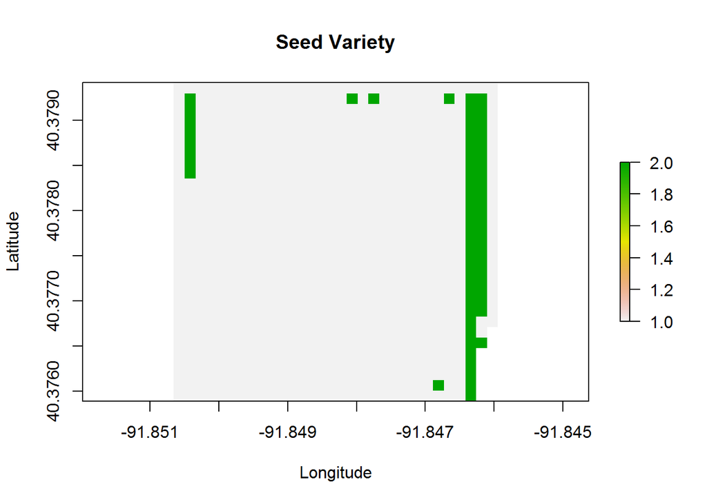

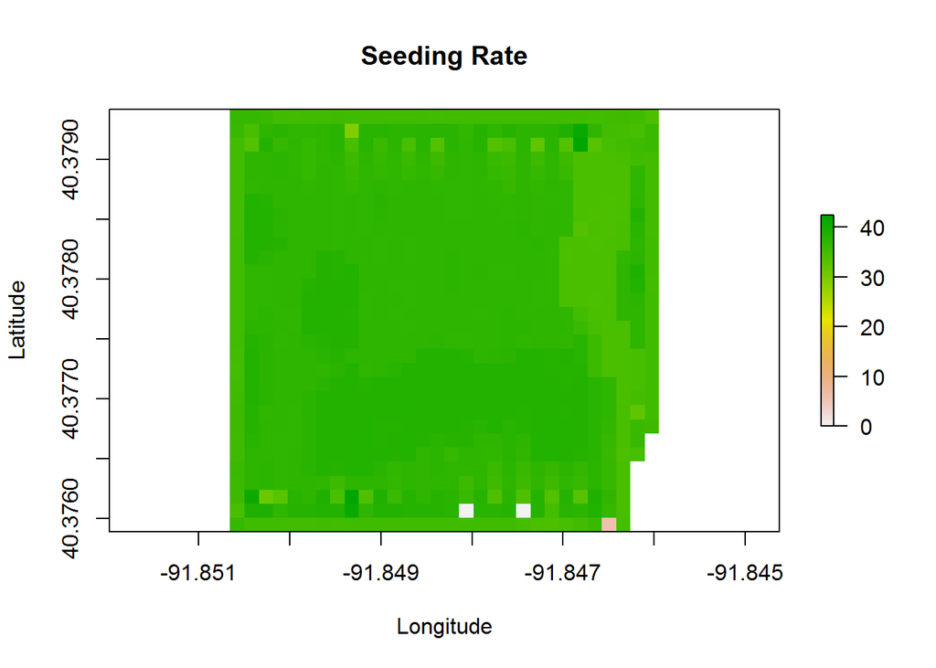

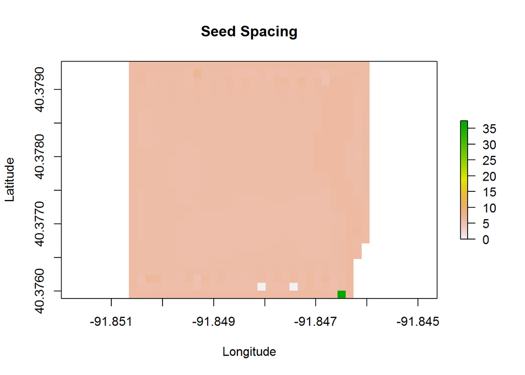

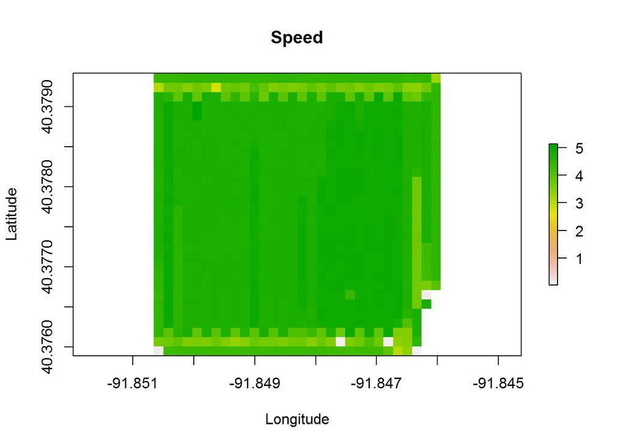

### Cleaning the Data

After looking at the raster plots of the extracted planting data, it looks like a few outliers are having a big impact on the data. I remove the highest 1% and lowest 1% of values and get rid of one NA value prior to analyzing the dataset.

# Exploratory Data Analysis

Now that there is planting-related data at each harvest location, I can begin the exploratory data analysis to identify potential predictors of better harvest yield. Since there is only one dependent variable (yield) and four potential independent variables (variety, seeding rate, seed spacing, and speed), I’ll take the time to look in depth at each variable.

### Yield

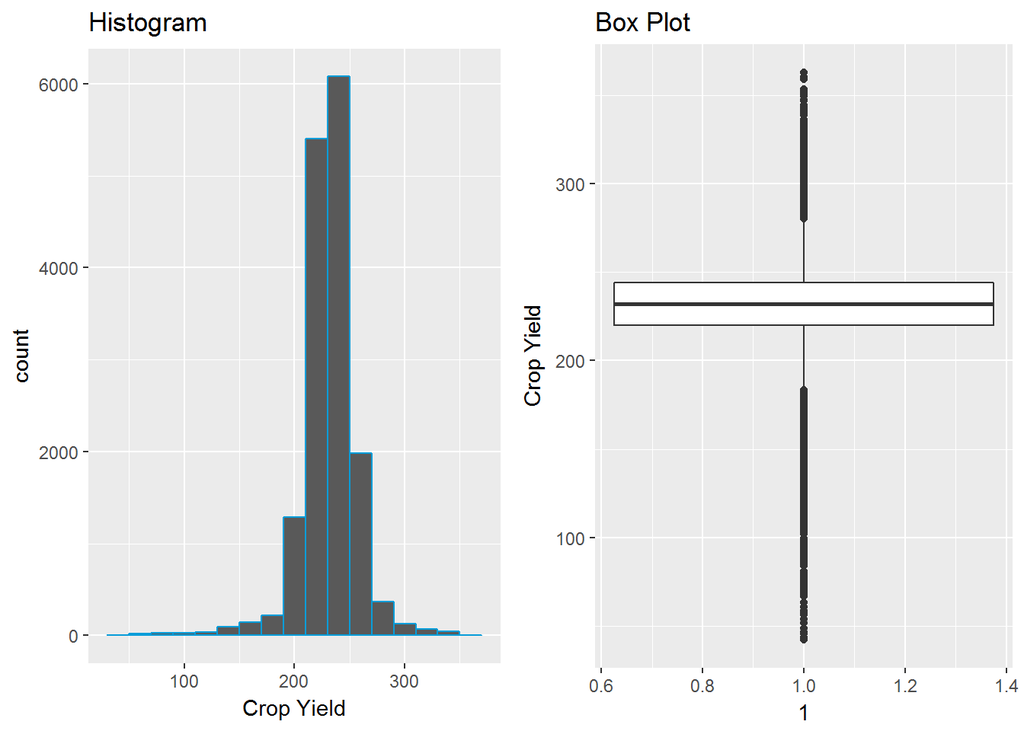

### Seed Variety

Seed variety is the only categorical variable in the dataframe. I take a look at a box plot and histogram of this variable to identify the distribution and any potential outliers. After plotting, each box plot appears normally distributed.

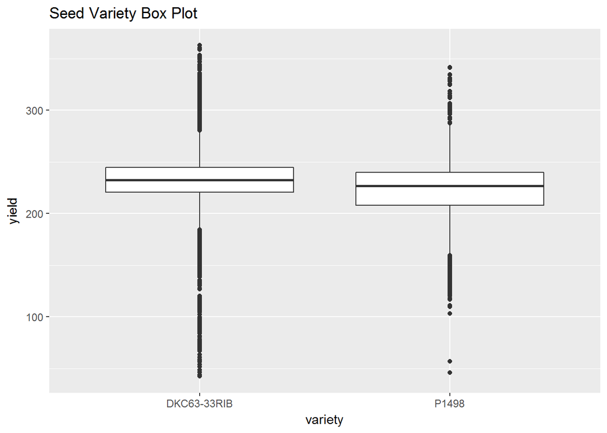

### Seeding Rate

The seeding rate is next. I take a look at a box plot and histogram of this variable to identify the distribution. The data actually looks bimodal, but I will assume a normal distribution for this analysis.

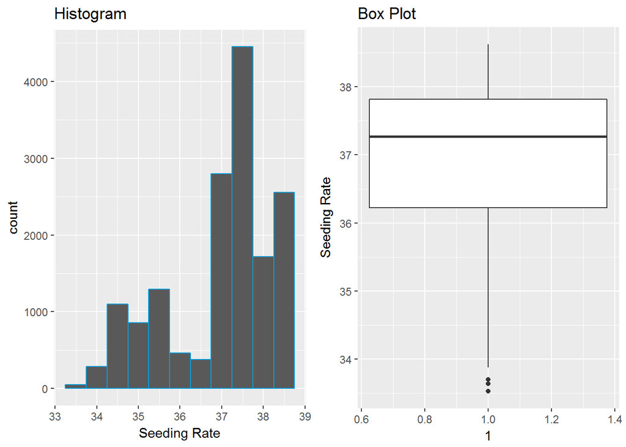

### Seed Spacing

I look at seed spacing next. I look at a box plot and histogram of this variable to identify the distribution. After plotting, the data appears to have a slight right skew, but I will assume it is normally distributed for this analysis.

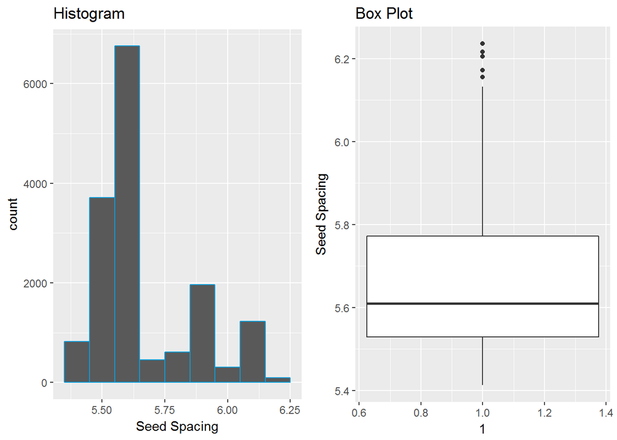

### Planting Speed

Next, I look at the speed. I take a look at a box plot and histogram of this variable to identify the distribution. After plotting, the data appears to be almost bimodal. I quickly plot the distribution with only one seed variety, but the histogram is still bimodal, so the seed variety is not the cause of the bimodal data. I will assume a normal distribution for this analysis.

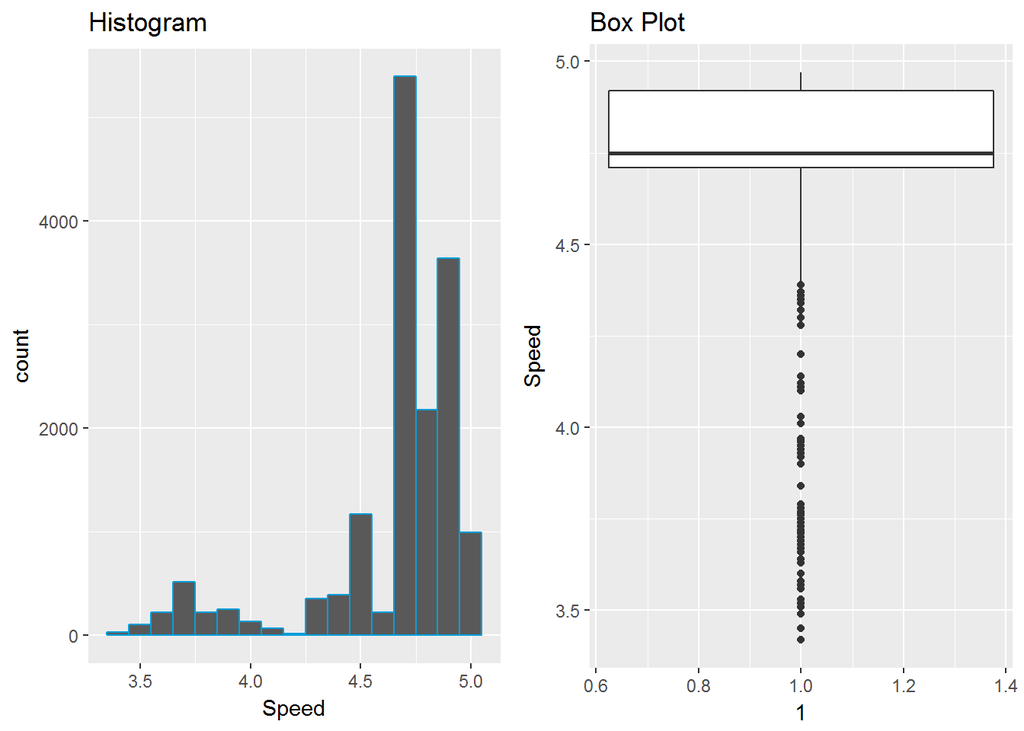

# Overview of Bivariate Relationships

Next, I look at the scatterplot of each variable against the crop yield.

### Seed Variety

For seed variety, I take a second look at the box plot and add a point for each mean. It looks like seed variety “DKC63-33RIB” shows slightly higher crop yield than seed variety “P1498.”

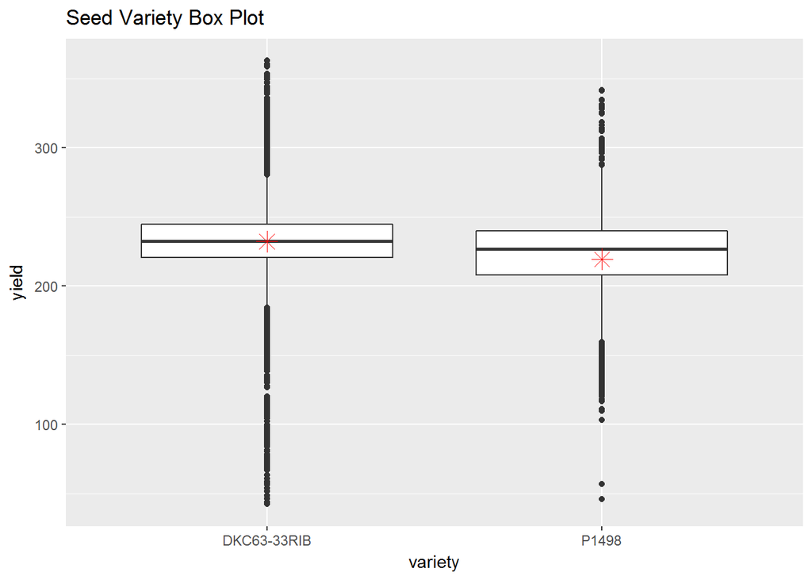

### Seeding Rate

The seeding rate does not look very correlated to crop yield.

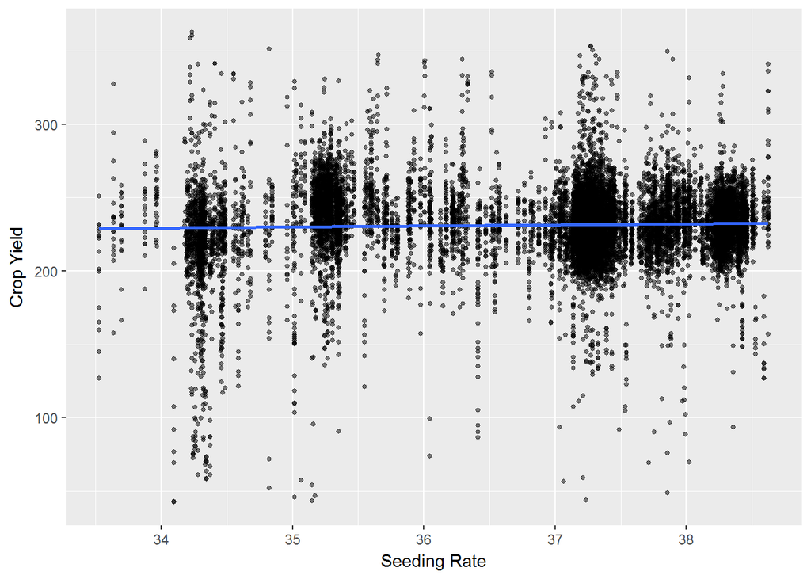

```
##
##  Pearson's product-moment correlation
##
## data:  clean_data$seeding_rate and clean_data$yield
## t = 4.3381, df = 15951, p-value = 1.446e-05
## alternative hypothesis: true correlation is not equal to 0
## 95 percent confidence interval:
##  0.01882020 0.04981943
## sample estimates:
##        cor
## 0.03432807
```

### Seed Spacing

Seed spacing does not look very correlated to higher crop yield, but is more promising than seeding rate and speed.

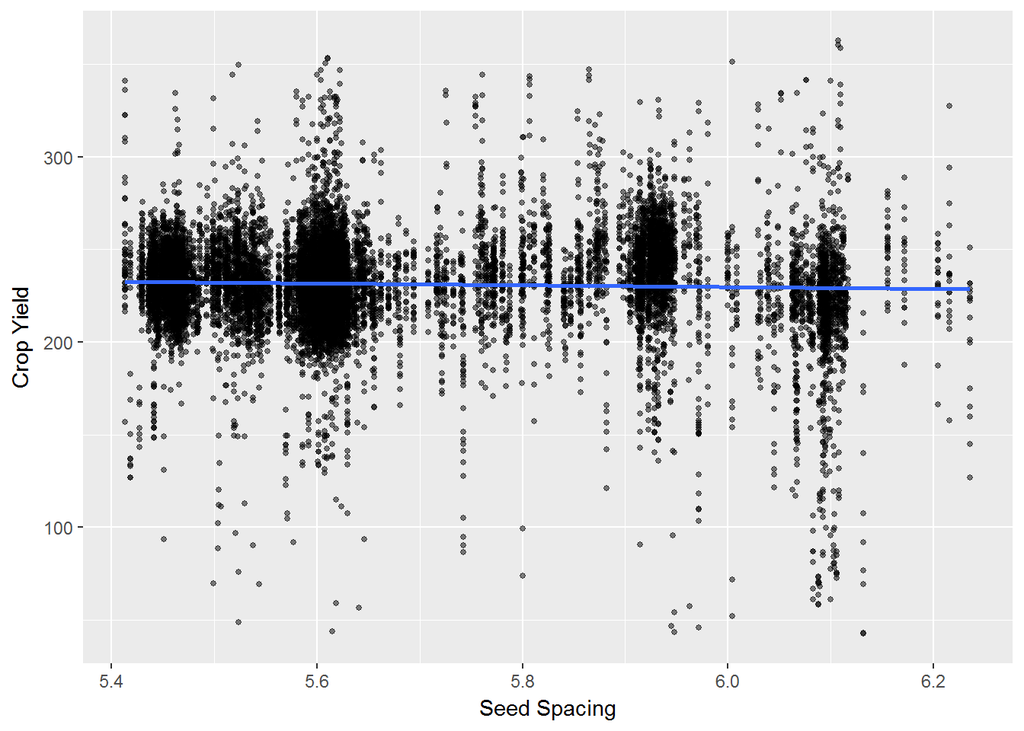

```
##
##  Pearson's product-moment correlation
##
## data:  clean_data$seed_spacing and clean_data$yield
## t = -4.6871, df = 15951, p-value = 2.794e-06
## alternative hypothesis: true correlation is not equal to 0
## 95 percent confidence interval:
##  -0.05257394 -0.02158082
## sample estimates:
##         cor
## -0.03708629
```

### Planting Speed

Planting speed does not appear to be very correlated to the crop yield.

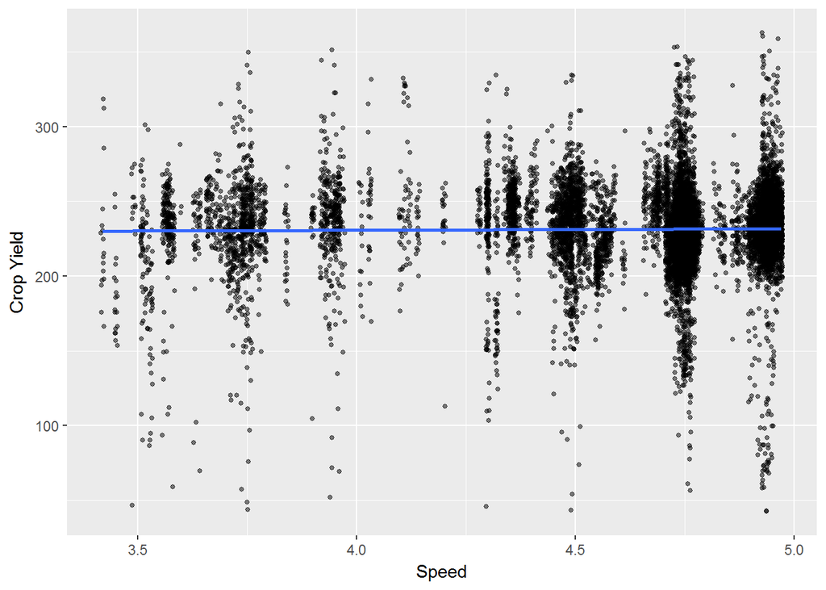

```
##
##  Pearson's product-moment correlation
##
## data:  clean_data$speed and clean_data$yield
## t = 1.6382, df = 15951, p-value = 0.1014
## alternative hypothesis: true correlation is not equal to 0
## 95 percent confidence interval:
##  -0.00254834  0.02848224
## sample estimates:
##        cor
## 0.01297007
```

# Multi-variate Plots

Next, I take a closer look at my two most promising variables: seed spacing and seed variety. I plot seed spacing against crop yield and split the data points by seed variety. It looks like seed variety “P1498” generally has lower yield values than seed variety “DKC63-33RIB”.

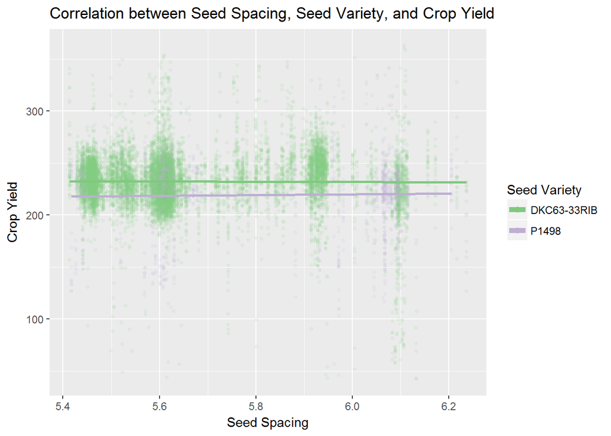

# Regression Model

Next, I create a regression model out of these variables. In the first model I only use the “Seed Spacing” variable to predict yield. In the second model I include both the “Seed Spacing” and “Seed Variety” variables to predict yield. In the third model I only include the “Seed Variety” variable to predict yield. I convert the seed varieties back to integers for insertion into the model.

Comparing the three models’ significance levels, F-statistic, and R-squared values, it looks like the seed variety is the best variable to use to predict the harvest yield.

```
##
## Call:
## lm(formula = yield ~ seed_spacing, data = clean_data)
##
## Residuals:
##      Min       1Q   Median       3Q      Max
## -187.807  -11.501    0.413   12.676  133.538
##
## Coefficients:
##              Estimate Std. Error t value Pr(>|t|)
## (Intercept)   258.954      5.896  43.923  < 2e-16 ***
## seed_spacing   -4.873      1.040  -4.687 2.79e-06 ***
## ---
## Signif. codes:  0 '***' 0.001 '**' 0.01 '*' 0.05 '.' 0.1 ' ' 1
##
## Residual standard error: 25.74 on 15951 degrees of freedom
## Multiple R-squared:  0.001375,   Adjusted R-squared:  0.001313
## F-statistic: 21.97 on 1 and 15951 DF,  p-value: 2.794e-06
```

```
##
## Call:
## lm(formula = yield ~ I(seed_spacing) + I(as.integer(variety)),
##     data = clean_data)
##
## Residuals:
##      Min       1Q   Median       3Q      Max
## -189.554  -11.749    0.311   12.815  130.737
##
## Coefficients:
##                        Estimate Std. Error t value Pr(>|t|)
## (Intercept)            248.6804     5.8846  42.259   <2e-16 ***
## I(seed_spacing)         -0.6396     1.0651  -0.601    0.548
## I(as.integer(variety)) -12.7807     0.8010 -15.956   <2e-16 ***
## ---
## Signif. codes:  0 '***' 0.001 '**' 0.01 '*' 0.05 '.' 0.1 ' ' 1
##
## Residual standard error: 25.54 on 15950 degrees of freedom
## Multiple R-squared:  0.01707,    Adjusted R-squared:  0.01694
## F-statistic: 138.5 on 2 and 15950 DF,  p-value: < 2.2e-16
```

```
##
## Call:
## lm(formula = yield ~ I(as.integer(variety)), data = clean_data)
##
## Residuals:
##      Min       1Q   Median       3Q      Max
## -189.860  -11.752    0.336   12.843  130.447
##
## Coefficients:
##                        Estimate Std. Error t value Pr(>|t|)
## (Intercept)            245.1841     0.8568  286.16   <2e-16 ***
## I(as.integer(variety)) -12.9005     0.7757  -16.63   <2e-16 ***
## ---
## Signif. codes:  0 '***' 0.001 '**' 0.01 '*' 0.05 '.' 0.1 ' ' 1
##
## Residual standard error: 25.54 on 15951 degrees of freedom
## Multiple R-squared:  0.01704,    Adjusted R-squared:  0.01698
## F-statistic: 276.6 on 1 and 15951 DF,  p-value: < 2.2e-16
```

# Analysis of Model Error

Plugging in the resulting linear regression equation and plotting the error reveals a normally distributed data set. But the residual error is fairly high (most falls within +/- 50) compared to the yield values (50-350).

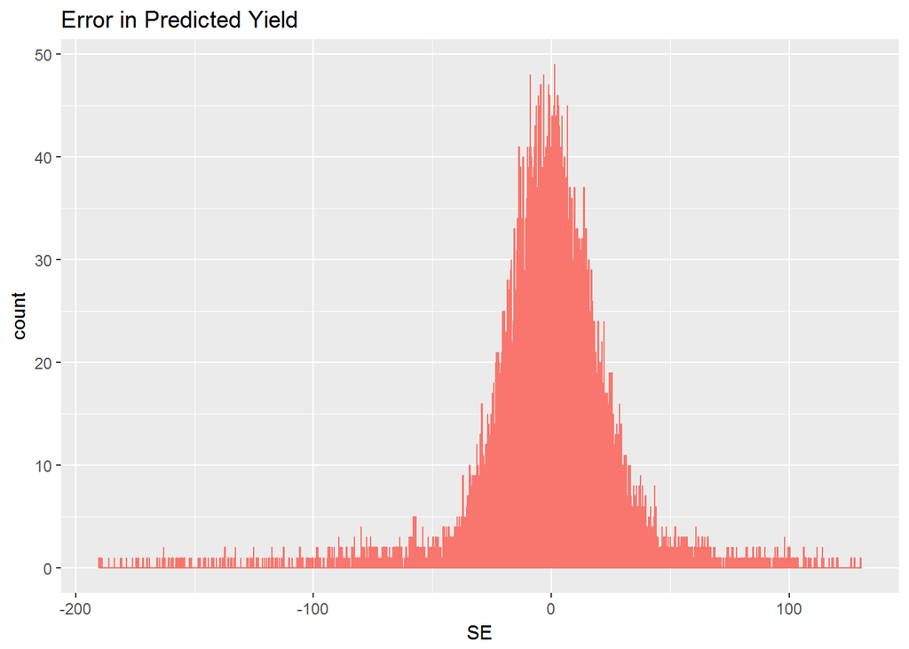

### Conclusions

After extracting the planting data into the locations where crop yield was recorded, I analyzed the correlations between the planting data and the associated crop yield data. After observing the distributions of the variables and removing outliers, it appeared that seed spacing and seed variety may exhibit correlation to crop yield. Insertion of each variable into a linear regression model demonstrated that the seed variety “DKC63-33RIB” may be correlated to higher crop yields compared to seed variety “P1498”. While the error of the linear regression model is normally distributed, the standard error and the model F-statistic and R-squared values do not give me a lot of confidence in my model results.

### Future Work

This model has a lot of room for improvement. Ideas to improve the model as well as improve the identification of variables correlated to higher crop yield include:

- Instead of extracting the planting data into the harvest yield, extract the harvest yield into the planting data. There will be a much smaller sample size, but the yield data may by more precisely associated with the planting data.
- Decrease the cell size of the raster and use multiple nearby cell values to extract the planting data.
- Collect additional data with the harvest yield, such as the soil moisture, nitrates, fertilizer, etc.
- Collect additional data throughout the crop cycle. For example, collect monthly soil moisture data and soil temperature data.